# 3. Estimate derivatives of a COVIDcast signal

In this vignette, we estimate derivatives of `covidcast` signals using the `estimate_deriv()` function from the `modeltools` package.

We’ll use the same reporting data here that we used in the previous vignettes. The code chunk below fetches the data from the [**Delphi API**](https://cmu-delphi.github.io/delphi-epidata/api/covidcast_signals.html).

```r
library(covidcast)
library(dplyr)

start_day <- "2020-06-01"
end_day <- "2020-11-15"
geo_values <- c("ca","fl","ny","tx")

case_rates <- covidcast_signal(data_source = "usa-facts",
                               signal = "confirmed_7dav_incidence_prop",
                               start_day = start_day,
                               end_day = end_day,
                               geo_type = "state",
                               geo_values = geo_values) %>%
  select(data_source, signal, geo_value, time_value, value)

case_rates %>%
  table_head(title = "Daily COVID-19 cases per 100,000 pop. (7-day trailing average)")
```

| Daily COVID-19 cases per 100,000 pop. (7-day trailing average) data_source | Daily COVID-19 cases per 100,000 pop. (7-day trailing average) signal | Daily COVID-19 cases per 100,000 pop. (7-day trailing average) geo_value | Daily COVID-19 cases per 100,000 pop. (7-day trailing average) time_value | Daily COVID-19 cases per 100,000 pop. (7-day trailing average) value |
| --- | --- | --- | --- | --- |
| usa-facts | confirmed_7dav_incidence_prop | ca | 2020-06-01 | 6.701 |
| usa-facts | confirmed_7dav_incidence_prop | fl | 2020-06-01 | 3.381 |
| usa-facts | confirmed_7dav_incidence_prop | ny | 2020-06-01 | 6.570 |
| usa-facts | confirmed_7dav_incidence_prop | tx | 2020-06-01 | 4.406 |
| usa-facts | confirmed_7dav_incidence_prop | ca | 2020-06-02 | 6.389 |
| usa-facts | confirmed_7dav_incidence_prop | fl | 2020-06-02 | 3.454 |

## Estimating derivatives

The `modeltools` function for estimating derivatives is called `estimate_deriv()`, and (in addition to a `covidcast_signal` data frame) takes two primary arguments:

1. `method` : a string indicating the method to use for derivative estimation,
2. `n` : a positive integer specifying the trailing number of days to use to train the given method.

### Estimating derivatives via linear regression

First we illustrate the default method for derivative estimation `method = "lin"`, which uses the slope from a simple linear regression. Here we also use the default trailing number of days `n = 14`.

```r
library(modeltools)
case_rates <- estimate_deriv(case_rates, method = "lin", n = 14)

case_rates %>%
  table_head(title = "Daily COVID-19 cases per 100,000 pop. (7-day trailing average)")
```

| Daily COVID-19 cases per 100,000 pop. (7-day trailing average) geo_value | Daily COVID-19 cases per 100,000 pop. (7-day trailing average) data_source | Daily COVID-19 cases per 100,000 pop. (7-day trailing average) signal | Daily COVID-19 cases per 100,000 pop. (7-day trailing average) time_value | Daily COVID-19 cases per 100,000 pop. (7-day trailing average) value | Daily COVID-19 cases per 100,000 pop. (7-day trailing average) deriv |
| --- | --- | --- | --- | --- | --- |
| ca | usa-facts | confirmed_7dav_incidence_prop | 2020-06-01 | 6.701 | NA |
| ca | usa-facts | confirmed_7dav_incidence_prop | 2020-06-02 | 6.389 | -0.312 |
| ca | usa-facts | confirmed_7dav_incidence_prop | 2020-06-03 | 6.497 | -0.102 |
| ca | usa-facts | confirmed_7dav_incidence_prop | 2020-06-04 | 6.863 | 0.059 |
| ca | usa-facts | confirmed_7dav_incidence_prop | 2020-06-05 | 7.109 | 0.129 |
| ca | usa-facts | confirmed_7dav_incidence_prop | 2020-06-06 | 6.808 | 0.087 |

Note above that a column `deriv` has been added to the output data frame, which contains the derivative estimates. Below we visualize these estimates in tandem with the signal itself. The red dots mark time points at which the derivative estimate exceeds an (arbitrarily chosen) threshold of 0.25. These seem to roughly but reasonably mark times of upswing in the underlying signal.

The `table_head` function used above is an internal function that we use in these tutorial vignettes to display table heads. The source code can be found in the `vignettes/estimate-deriv.Rmd` file used to build this page.

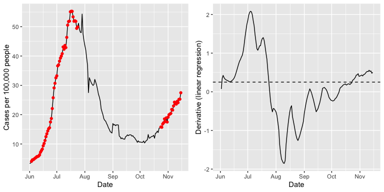

```r
library(ggplot2)
library(gridExtra)

state <- "fl"
threshold <- 0.25

p1 <- ggplot(case_rates %>% filter(geo_value == state), aes(x = time_value, y = value)) +
  geom_line() +
  geom_point(data = case_rates %>% filter(geo_value == state, deriv >= threshold),
             aes(x = time_value, y = value), color = "red") +
  labs(x = "Date", y = "Cases per 100,000 people")

p2 <- ggplot(case_rates %>% filter(geo_value == state), aes(x = time_value, y = deriv)) +
  geom_line() +
  geom_hline(yintercept = threshold, linetype = 2) +
  labs(x = "Date", y = "Derivative (linear regression)")

grid.arrange(p1, p2, nrow = 1)
```

### Estimating derivatives via smoothing spline

Now we consider `method = "ss"`, which uses a smoothing spline to estimate the derivative of a `covidcast` signal. In particular, at each time point, we fit a natural cubic spline to the data from the trailing `n` days, and return the derivative of the underlying fitted spline at the current time as the estimate. Here we set `n = 28`, a bit higher sample size, and fit the spline in two ways: first, by fixing the degrees of freedom to be 8; and second, using cross-validation to choose the amount of regularization (tuning parameter). This is accomplished by passing additional arguments to `estimate_deriv()`, which are in turn passed on to the underlying function it uses to fit smoothing splines (`stats::smooth.spline()`). Note that we also set a custom name for the output column with the estimated derivatives, via the `col_name` argument of `estimate_deriv()`.

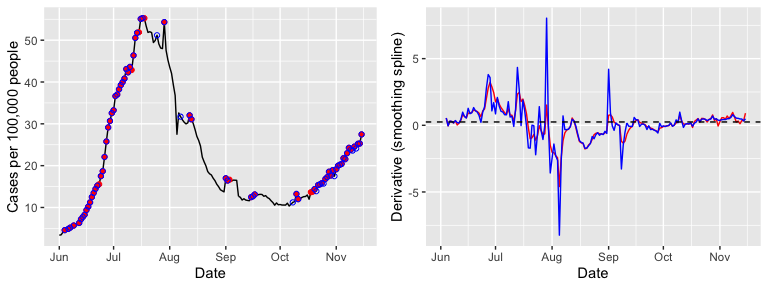

```r
case_rates <- estimate_deriv(case_rates, method = "ss", n = 28,
                             col_name = "deriv_ss1", df = 8)

case_rates <- estimate_deriv(case_rates, method = "ss", n = 28,
                             col_name = "deriv_ss2", cv = T)

p1 <- ggplot(case_rates %>% filter(geo_value == state),
             aes(x = time_value, y = value)) +
  geom_line() +
  geom_point(data = case_rates %>%
               filter(geo_value == state, deriv_ss1 >= threshold),
             aes(x = time_value, y = value), color = "red") +
  geom_point(data = case_rates %>%
               filter(geo_value == state, deriv_ss2 >= threshold),
             aes(x = time_value, y = value), color = "blue", shape = 21) +
  labs(x = "Date", y = "Cases per 100,000 people")

p2 <- ggplot(case_rates %>% filter(geo_value == state), aes(x = time_value)) +
  geom_line(aes(y = deriv_ss1), color = "red") +
  geom_line(aes(y = deriv_ss2), color = "blue") +
  geom_hline(yintercept = threshold, linetype = 2) +
  labs(x = "Date", y = "Derivative (smoothing spline)")

grid.arrange(p1, p2, nrow = 1)
```

### Estimating derivatives via trend filtering

Lastly we consider `method = "tf"`, which uses trend filtering [(Tibshirani 2014)](https://projecteuclid.org/euclid.aos/1395234979) for estimating the derivative. That is, at each time point, we fit a discrete spline of quadratic order to the data from the trailing `n` days, and return the discrete derivative of the underlying fitted spline at the current time as the estimate. As before, we fit the spline in two ways: first, using a fixed degrees of freedom of 8; and second, using cross-validation to choose the amount of regularization. Since the optimization here takes a while (it’s based on computing a full solution path for the trend filtering problem, via the `genlasso::trendfilter()` function), we only compute derivatives for Florida.

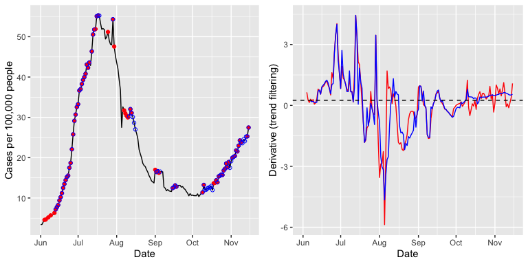

```r
case_rates_state <- case_rates %>% filter(geo_value == state)

case_rates_state <- estimate_deriv(case_rates_state, method = "tf", n = 28,
                                   col_name = "deriv_tf1", df = 8)

case_rates_state <- estimate_deriv(case_rates_state, method = "tf", n = 28,
                                   col_name = "deriv_tf2", cv = T)

p1 <- ggplot(case_rates_state, aes(x = time_value, y = value)) +
  geom_line() +
  geom_point(data = case_rates_state %>% filter(deriv_tf1 >= threshold),
             aes(x = time_value, y = value), color = "red") +
  geom_point(data = case_rates_state %>% filter(deriv_tf2 >= threshold),
             aes(x = time_value, y = value), color = "blue", shape = 21) +
  labs(x = "Date", y = "Cases per 100,000 people")

p2 <- ggplot(case_rates_state, aes(x = time_value)) +
  geom_line(aes(y = deriv_tf1), color = "red") +
  geom_line(aes(y = deriv_tf2), color = "blue") +
  geom_hline(yintercept = threshold, linetype = 2) +
  labs(x = "Date", y = "Derivative (trend filtering)")

grid.arrange(p1, p2, nrow = 1)
```

The estimated derivatives now appear a bit smoother than the last ones, from the smoothing spline methods. Again, using cross-validation offers a noticeable improvement in adapting to to the time-varying level of smoothness, as is very clear from the differences between red and blue derivative estimates in October and November.